# Comparison of Spark Classifiers Using Sparklyr

# Overview

This [R Notebook](https://rmarkdown.rstudio.com/r_notebooks.html) will demonstrate how to fit and compare classification models in Spark using the R package [Sparklyr](http://spark.rstudio.com/).

Models will include the Spark ML routines for logistic regression, decision trees, gradient boosted trees, random forest, and multi-layer perceptron (nueral net) and naive bayes.

The article will cover:

- Loading the Data
- Feature Engineering
- Value Imputation
- Model Building
- Model Comparison

Jump to the results!

# Loading the Data

The analysis will use the popular Titanic kaggle dataset. A thorough background on the dataset and examples of analysis are available [here](https://www.kaggle.com/c/titanic). The goal is to predict whether an individual survived or died based on factors including their class, gender, age, and family. The titanic data is readily available in R in the titanic package. The dataset is small (891 rows), but the methods presented are applicable to real Spark datasets.

We’ll work in a local Spark cluster and read the data in from parquet. The parquet files were generated through the following one-time process:

```r
library(titanic)
copy_to(sc, titanic_train, "titanic")
tbl(sc, "titanic") %>% spark_write_parquet(path = "titanic-parquet")
```

Given parquet data, it suffices to launch Spark locally and read the parquet files in directly. The analysis is done in Spark 2.0, but most of the analysis can be replicated in earlier versions.

```r
sc <- spark_connect(master = "local", version = "2.0.0")
spark_read_parquet(sc, name = "titanic", path = "titanic-parquet")
titanic_tbl <- tbl(sc, "titanic")
```

# Feature Engineering - dplyr

While this dataset contains some helpful predictions, we’ll demo how to create additional features in Sparklyr using dplyr commands.

| Variable | Definition |
| --- | --- |
| Family_Size | Number of Siblings and Parents |
| Mother | A women with at least one child |
| Father | A male with at least one son |

```r
titanic2_tbl <- titanic_tbl %>%
  mutate(Family_Size = SibSp + Parch + 1) %>%
  mutate(Father = if_else(Sex == "male" & Age > 18 & Parch > 0, 1,0)) %>%
  mutate(Mother = if_else(Sex == "female" & Age > 18 & Parch > 0, 1,0)) %>%
  compute() %>%
  sdf_register("titanic2")
```

> Sparklyr Tip: `compute` is used to force the execution of our dplyr chain, and `sdf_register` is used to save our table for later analysis.

# Value Imputation

This section is optional. There are many ways to account for missing values and different methods could impact relative model performance. In this case, we’ll impute the missing age values using linear regression to generate a complete dataset. This dataset will be used to train and test all of the models.

For imputation a linear model is fit on the complete observations and used to score missing values. `sdf_predict` is used to score the missing values.

```r
m <- titanic2_tbl %>%
  na.omit() %>%
  ml_linear_regression(Age ~ Pclass + Sex + SibSp + Parch + Fare + Father + Mother)
summary(m)

titanic3_tbl <- sdf_predict(m, titanic2_tbl) %>%
  sdf_register("titanic3")
```

> Sparklyr Tip: The `sdf_predict` function creates a new Spark Data Frame which we preserve and make accessible using `sdf_register`

The imputated data can be evaluated by comparing the distribution age in the complete observations and the modeled observations.

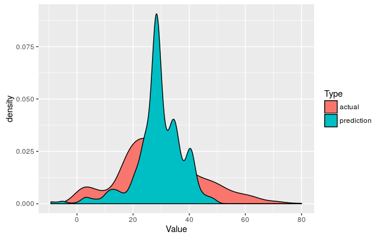

```r
titanic3_tbl %>%
  mutate(error = Age - prediction) %>%
  select(Age, prediction) %>%
  rename(actual = Age) %>%
  collect() %>%
  gather("Type", "Value") %>%
  ggplot(aes(x = Value, fill = Type)) + geom_density()
```

The linear model used for imputation can also be evaluated by plotting the scored predictions against the true data for the complete observations.

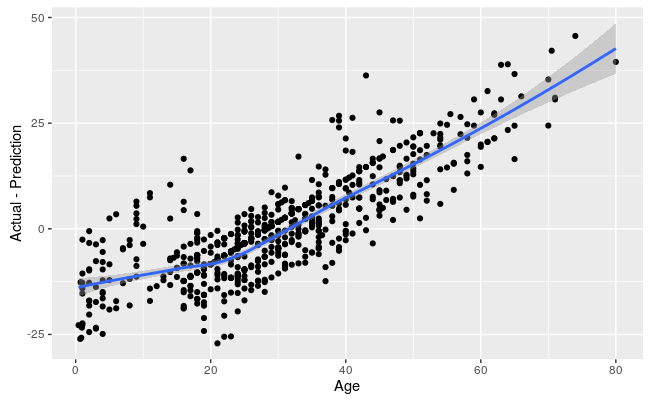

```r
titanic3_tbl %>%
  mutate(error = Age - prediction) %>%
  select(error, Age) %>%
  collect() %>%
  ggplot(aes(y = error, x = Age)) + geom_point() + geom_smooth() + ylab("Actual - Prediction")
```

The results of these two evaluations aren’t inspiring. There is evidence of hetero-skedasticity and a bias to under-predict age. However, for the sake of the demo we’ll move forward with the imputed dataset.

# Feature Engineering - ML Feature Transformers

Now that age has been added, another feature will be created using one of the Spark ML feature transformers. Specifically, a bucketized variable to represent the age bins: child, teen, adult, and retired.

```r
titanic_final_tbl <- titanic3_tbl %>%
  mutate(Age = if_else(is.na(Age), prediction, Age)) %>%
  mutate(Age = if_else(Age < 0, 0, Age)) %>%
  select(-prediction, -Sex_male, - Sex_female) %>%
  sdf_mutate(Age_Class = ft_bucketizer(input_col = Age,
                                       splits = c(0,12,18,65,Inf))) %>%
  sdf_register("titanic_final")
```

> Sparklry Tip: In a dplyr pipeline, feature transformers are used in conjunction with `sdf_mutate`

The last step in preparing the data is to define a training and testing partition.

```r
partition <- titanic_final_tbl %>%
  sdf_partition(train = 0.75, test = 0.25)
test <- partition$test
train <- partition$train
```

> Sparklyr Tip: Use sdf_partition to create training and testing splits.

# Model Building

The following section contains code used to construct the different ml models. One of the great features of Sparklyr is that each algorithm accepts R formulas making it easy to create and compare models.

## Logistic Regression

```r
logistic <- train %>%
  ml_logistic_regression(Survived ~ Pclass + Sex + SibSp + Parch + Family_Size + Father + Mother + Age_Class + Age )
logistic
```

```
Call: Survived ~ Pclass + Sex_male + SibSp + Parch + Family_Size + Father + Mother + Age_Class + Age

Coefficients:
(Intercept)      Pclass    Sex_male       SibSp       Parch Family_Size      Father
 4.76638866 -1.12482037 -2.68759231 -1.52812236 -1.20841495  1.07285224 -0.72731893
     Mother   Age_Class         Age
 0.62360196 -0.46380757 -0.03239976
```

## Decision Tree

```r
decision <- train %>%
  ml_decision_tree(Survived ~ Pclass + Sex + SibSp + Parch + Family_Size + Father + Mother + Age_Class + Age)
summary(decision)
```

```
                            Length Class      Mode
features                    9      -none-     character
response                    1      -none-     character
max.bins                    1      -none-     numeric
max.depth                   1      -none-     numeric
categorical.transformations 1      -none-     environment
data                        2      spark_jobj environment
model.parameters            5      -none-     list
.call                       3      -none-     call
.model                      2      spark_jobj environment
```

## Random Forest

```r
rf <- train %>%
  ml_random_forest(Survived ~ Pclass + Sex + SibSp + Parch + Family_Size + Father + Mother + Age_Class + Age )
summary(rf)
```

```
                            Length Class      Mode
features                     9     -none-     character
response                     1     -none-     character
max.bins                     1     -none-     numeric
max.depth                    1     -none-     numeric
num.trees                    1     -none-     numeric
feature.importances          9     -none-     numeric
trees                       20     -none-     list
data                         2     spark_jobj environment
categorical.transformations  1     -none-     environment
model.parameters             5     -none-     list
.call                        3     -none-     call
.model                       2     spark_jobj environment
```

## Gradient Boosted Tree

```r
gbt <- train %>%
  ml_gradient_boosted_trees(Survived ~ Pclass + Sex + SibSp + Parch + Family_Size + Father + Mother + Age_Class + Age )
summary(gbt)
```

```
                            Length Class      Mode
features                     9     -none-     character
response                     1     -none-     character
max.bins                     1     -none-     numeric
max.depth                    1     -none-     numeric
trees                       20     -none-     list
data                         2     spark_jobj environment
categorical.transformations  1     -none-     environment
model.parameters             5     -none-     list
.call                        3     -none-     call
.model                       2     spark_jobj environment
```

## Naive Bayes

```r
nb <- train %>%
  ml_naive_bayes(Survived ~ Pclass + Sex + SibSp + Parch + Family_Size + Father + Mother + Age_Class + Age )
summary(nb)
```

```
                            Length Class      Mode
pi                          2      spark_jobj environment
theta                       2      spark_jobj environment
features                    9      -none-     character
response                    1      -none-     character
data                        2      spark_jobj environment
categorical.transformations 1      -none-     environment
model.parameters            5      -none-     list
.call                       3      -none-     call
.model                      2      spark_jobj environment
```

## Nueral Network

```r
nn <- train %>%
  ml_multilayer_perceptron(Survived ~ Pclass + Sex + SibSp + Parch + Family_Size + Father + Mother + Age_Class + Age, layers = c(9,15,2))
summary(nn)
```

```
                            Length Class      Mode
features                    9      -none-     character
response                    1      -none-     character
data                        2      spark_jobj environment
categorical.transformations 1      -none-     environment
model.parameters            5      -none-     list
.call                       4      -none-     call
.model                      2      spark_jobj environment
```

## Training Time

Even with a samll dataset the time to train an ml algorithm is important. The following code trains each model `n` times and plots the results. (Training the multi-layer perceptron model took noticeably longer and was not included)

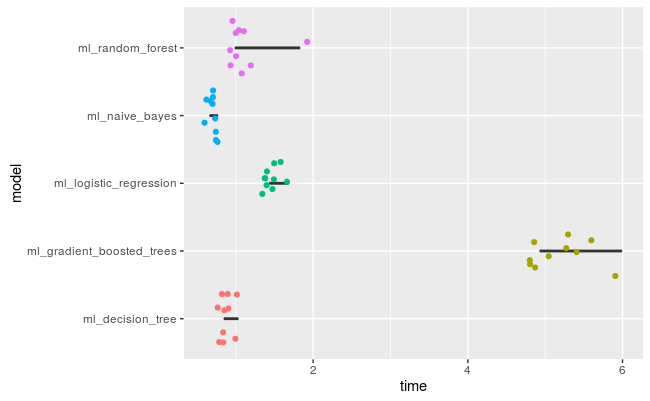

```r
formula <- "Survived ~ Pclass + Sex + SibSp + Parch + Family_Size + Father + Mother + Age_Class + Age"
models <- c("ml_logistic_regression", "ml_decision_tree",
            "ml_random_forest", "ml_gradient_boosted_trees",
            "ml_naive_bayes")
model_call <- map2_chr("system.time(train %>% " , models, paste, sep = "") %>%
  map2_chr("(", paste, sep = "") %>%
  map2_chr(formula, paste, sep = "") %>%
  map2_chr("))", paste, sep = "")
n <- 10
calls <- rep(model_call, n)
f <- vector(length = length(model_call)*n )
for (i in 1:length(calls)) {
  f[i] <- parse(text = calls[i])
}
res  <- map(f, eval)
result <- data.frame(model = rep(models, n),
                     time = sapply(res, function(x){as.numeric(x["elapsed"])}))
result %>% ggplot(aes(time,model)) +
  geom_boxplot() +
  geom_jitter(width = 0.4, aes(colour = model)) +
  scale_colour_discrete(guide = FALSE)
```

# Model Comparison

This section compares the models:

- Training Confusion Matrix
- Feature Importance
- Lift Chart
- Area Under ROC
- Accuracy

## Training

To begin, it is possible to evaluate how well the models work on the training data. For this comparison a confusion matrix is constructed for each model. To create the confusion matrix it is necessary to take the scored probabilites and map them to predictions. 0.5 is used as a cutoff.

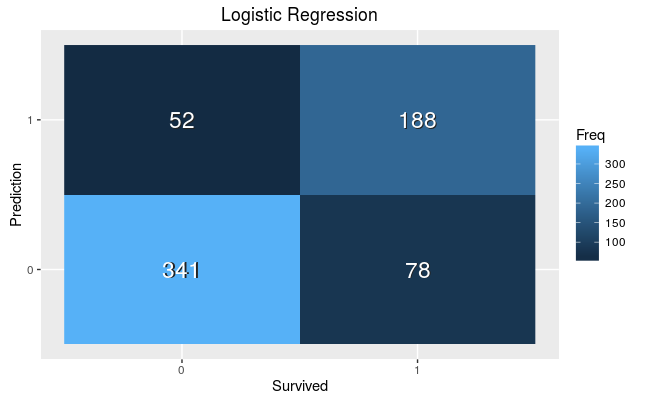

```r
plot_confusion_matrix <- function(prediction_tbl_spark, title) {
  #prediction column should be a binary label
  prediction_tbl_spark %>%
    select(Survived, prediction) %>%
    collect() %>%
    table() %>%
    as.data.frame() %>%
    ggplot() +
      geom_raster(aes(Survived, prediction, fill = Freq)) +
      geom_text(aes(Survived, prediction, label = Freq), col = "#222222", size = 6, nudge_x = 0.005, nudge_y = -0.005) +
      geom_text(aes(Survived, prediction, label = Freq), col = "white", size = 6) +
      labs(
        x = "Survived",
        y = "Prediction",
        title = title)
}
sdf_predict(logistic, train) %>%
  plot_confusion_matrix("Logistic Regression")
```

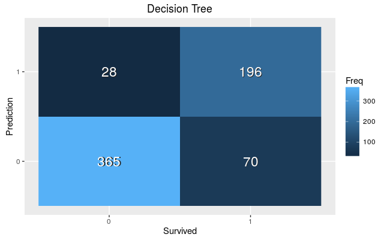

```r
sdf_predict(decision, train) %>%
  mutate(prediction = as.numeric(if_else(prediction > 0.5, 1, 0))) %>%
  plot_confusion_matrix("Decision Tree")
```

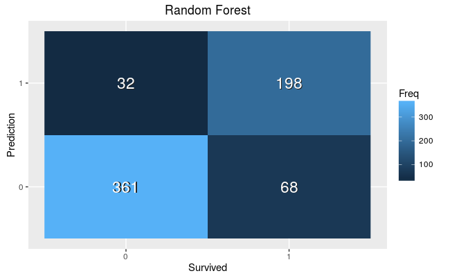

```r
sdf_predict(rf, train) %>%
  mutate(prediction = as.numeric(if_else(prediction > 0.5, 1, 0))) %>%
  plot_confusion_matrix("Random Forest")
```

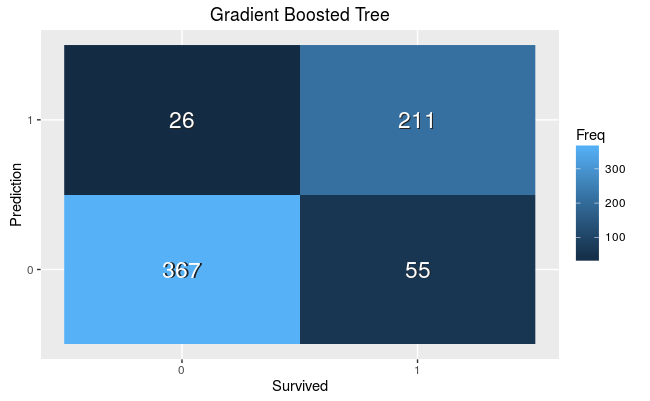

```r
sdf_predict(gbt, train) %>%
  mutate(prediction = as.numeric(if_else(prediction > 0.5, 1, 0))) %>%
  plot_confusion_matrix("Gradient Boosted Tree")
```

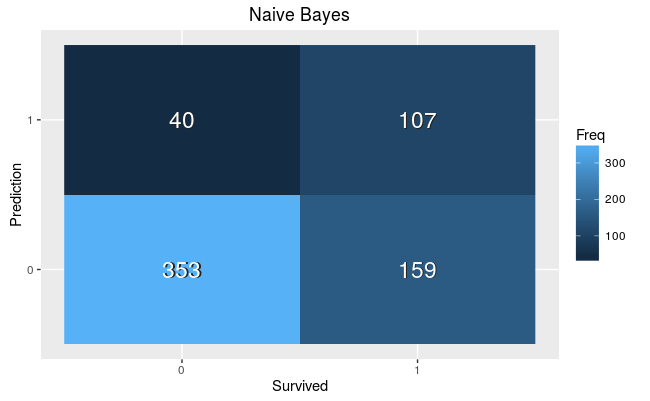

```r
sdf_predict(nb, train) %>%
  mutate(prediction = as.numeric(if_else(prediction > 0.5, 1, 0))) %>%
  plot_confusion_matrix("Naive Bayes")
```

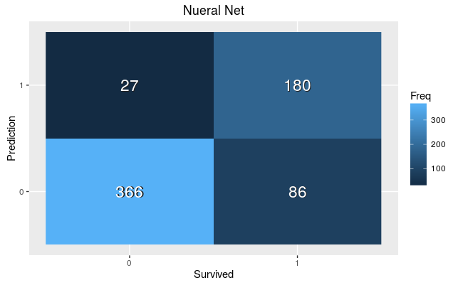

```r
sdf_predict(nn, train) %>%
  mutate(prediction = as.numeric(if_else(prediction > 0.5, 1, 0))) %>%
  plot_confusion_matrix("Nueral Net")
```

All of the models tend to over predict death. This is likely because the training data is not balanced, there were a lot more people who died on the titanic than survived.

## Feature Importance

It is also interesting to compare the features that were identified by each model as being important predictors for survival. The logistic regression and tree models in Spark 2.0.0 implement feature importance metrics. The relative importance of each feature is compared below by model.

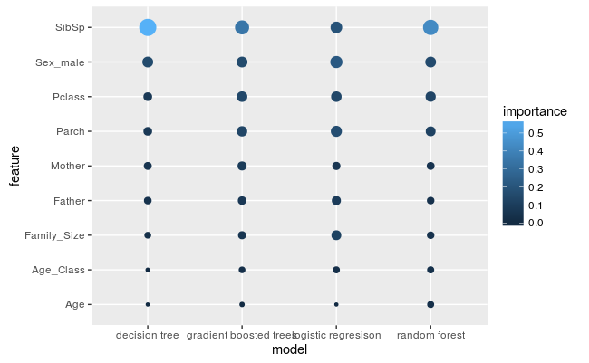

```r
l.res <- coefficients(logistic)
l.res <- data.frame(feature = names(l.res),
                    importance = as.numeric(l.res),
                    model = "logistic regresison",
                    stringsAsFactors = FALSE)
l.res <- l.res %>%
  mutate(importance = abs(importance)) %>%
  filter(feature != '(Intercept)') %>%
  mutate(importance = percent_rank(importance)/n()*2)

clean_up <- function(x, model){
  x %>%
    mutate(importance = as.numeric(levels(importance))) %>%
    mutate(feature = as.character(levels(feature))) %>%
    mutate(model = model)
}
#Features
d.res <- sparklyr:::ml_tree_feature_importance(sc, decision) %>% clean_up("decision tree")
rf.res <- sparklyr:::ml_tree_feature_importance(sc, rf) %>% clean_up("random forest")
gbt.res <- sparklyr:::ml_tree_feature_importance(sc, gbt) %>% clean_up("gradient boosted trees")
l.res %>%
  full_join(d.res) %>%
  full_join(rf.res) %>%
  full_join(gbt.res) %>%
  ggplot(aes(x = model, y = feature, colour = importance, size = importance)) +
  geom_point() + scale_size(guide = FALSE)
```

The number of siblings aboard and gender appear to be the most influential.

Arguably the most important comparison is how the models perform outside of the training data. Three metrics are used to compare model performance on the testing dataset: lift, Area Under the ROC curve, and accuracy.

## Lift Chart

A cummulative gains lift chart compares model performance across different portions of the data for a single cutoff value (0.5). This is different from an ROC curve which contains information about model performance for many cutoff values. ROC is harder compute and is not implemented yet for ML algorithms. In a lift chart models that approach the upper left corner perform the best.

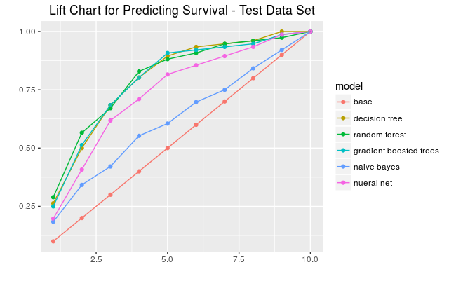

```r
models <- list(decision, rf, gbt, nb, nn)
model_names <- c("decision tree", "random forest",
                 "gradient boosted trees", "naive bayes", "nueral net")
survived <- (test %>%
  filter(Survived == 1) %>%
  count() %>%
  as.data.frame())$n
# Predicting Survival
gains_survived <- function(prediction){
  prediction %>%
    select(Survived, prediction) %>%
    arrange(desc(prediction)) %>%
    mutate(bin = ntile(desc(prediction), 10)) %>%
    group_by(bin) %>%
    summarize(count = sum(Survived)) %>%
    mutate(prop = as.numeric(count / survived)) %>%
    arrange(bin) %>%
    mutate(prop = cumsum(prop)) %>%
    select(-count) %>%
    collect() %>%
    as.data.frame()
}
gains <- data.frame(bin = 1:10,
                    prop = seq(0.1, 1, by = 0.1),
                    model = rep("base",10))
for (i in 1:length(models) ) {
  g <- sdf_predict(models[[i]], test) %>% gains_survived()
  g <- g %>% mutate(model = model_names[i])
  gains <- rbind(gains, g)
}
ggplot(gains, aes(x = bin, y = prop, colour = model)) +
  geom_point() + geom_line() +
  ggtitle("Lift Chart for Predicting Survival - Test Data Set") +
  xlab("") + ylab("")
```

> Sparklyr Tip: dplyr and sparklyr both support windows functions, including `ntiles` and `cumsum`.

The lift charts suggests that any of the tree models (random forest, gradient boosted trees, or the decision tree) will provide the best prediction.

## Area under ROC

Though ROC curves are not available, Spark ML does have support for Area Under the ROC curve. This metric captures performance across cut-off values, the higher the AUC the better

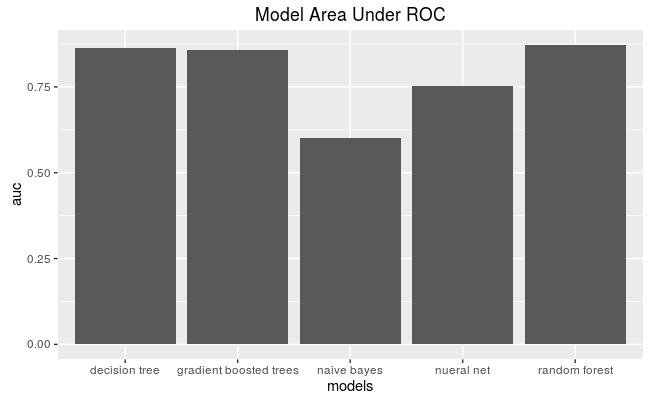

```r
rf.auc <- sdf_predict(rf, test) %>%
    select(prediction, Survived) %>%
    sparklyr:::ml_binary_classification_eval(metric = "areaUnderROC",label = "Survived", score = "prediction")
gbt.auc <- sdf_predict(gbt, test) %>%
    select(prediction, Survived) %>%
    sparklyr:::ml_binary_classification_eval(metric = "areaUnderROC",label = "Survived", score = "prediction")
nn.auc <- sdf_predict(nn, test) %>%
    select(prediction, Survived) %>%
    sparklyr:::ml_binary_classification_eval(metric = "areaUnderROC",label = "Survived", score = "prediction")
nb.auc <- sdf_predict(nb, test) %>%
    select(prediction, Survived) %>%
    sparklyr:::ml_binary_classification_eval(metric = "areaUnderROC",label = "Survived", score = "prediction")
d.auc <- sdf_predict(decision, test) %>%
    select(prediction, Survived) %>%
    sparklyr:::ml_binary_classification_eval(metric = "areaUnderROC",label = "Survived", score = "prediction")
auc_cmp <-
  data.frame(models = c("decision tree", "random forest",
                        "gradient boosted trees", "naive bayes",
                        "nueral net"),
             auc = c(d.auc, rf.auc, gbt.auc, nb.auc, nn.auc))
ggplot(auc_cmp, aes(models, auc)) +
  geom_bar(stat = "identity") +
  ggtitle("Model Area Under ROC")
```

## Accuracy

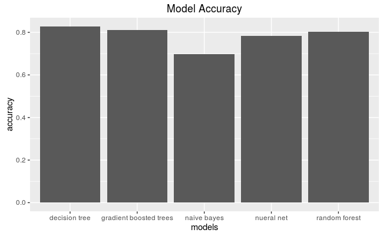

```r
rf.a <- sdf_predict(rf, test) %>%
    select(prediction, Survived) %>%
    mutate(prediction_lbl = ifelse(prediction > 0.5, 1.0, 0.0)) %>%
    mutate(prediction_lbl = as.double(prediction_lbl)) %>%
    sparklyr:::ml_classification_eval(metric = "accuracy",label = "Survived", predicted_lbl = "prediction_lbl")
nb.a <- sdf_predict(nb, test) %>%
    select(prediction, Survived) %>%
    mutate(prediction_lbl = ifelse(prediction > 0.5, 1.0, 0.0)) %>%
    mutate(prediction_lbl = as.double(prediction_lbl)) %>%
    sparklyr:::ml_classification_eval(metric = "accuracy",label = "Survived", predicted_lbl = "prediction_lbl")
nn.a <- sdf_predict(nn, test) %>%
    select(prediction, Survived) %>%
    mutate(prediction_lbl = ifelse(prediction > 0.5, 1.0, 0.0)) %>%
    mutate(prediction_lbl = as.double(prediction_lbl)) %>%
    sparklyr:::ml_classification_eval(metric = "accuracy",label = "Survived", predicted_lbl = "prediction_lbl")
gbt.a <- sdf_predict(gbt, test) %>%
    select(prediction, Survived) %>%
    mutate(prediction_lbl = ifelse(prediction > 0.5, 1.0, 0.0)) %>%
    mutate(prediction_lbl = as.double(prediction_lbl)) %>%
    sparklyr:::ml_classification_eval(metric = "accuracy",label = "Survived", predicted_lbl = "prediction_lbl")
decision.a <- sdf_predict(decision, test) %>%
    select(prediction, Survived) %>%
    mutate(prediction_lbl = ifelse(prediction > 0.5, 1.0, 0.0)) %>%
    mutate(prediction_lbl = as.double(prediction_lbl)) %>%
    sparklyr:::ml_classification_eval(metric = "accuracy",label = "Survived", predicted_lbl = "prediction_lbl")
accuracy_cmp <-
  data.frame(models = c("decision tree", "random forest",
                        "gradient boosted trees", "naive bayes",
                        "nueral net"),
             accuracy = c(decision.a, rf.a, gbt.a, nb.a, nn.a))
ggplot(accuracy_cmp, aes(models, accuracy)) + geom_bar(stat = "identity") + ggtitle("Model Accuracy")
```